# df

Autogenerated data summary from dataMaid

2021-06-22 20:51:50

# Data report overview

The dataset examined has the following dimensions:

| Feature | Result |
| --- | --- |
| Number of observations | 470 |
| Number of variables | 17 |

### Checks performed

The following variable checks were performed, depending on the data type of each variable:

|  | character | factor | labelled | haven labelled | numeric | integer | logical | Date |
| --- | --- | --- | --- | --- | --- | --- | --- | --- |
| Identify miscoded missing values | × | × | × | × | × | × |  | × |
| Identify prefixed and suffixed whitespace | × | × | × | × |  |  |  |  |
| Identify levels with < 6 obs. | × | × | × | × |  |  |  |  |
| Identify case issues | × | × | × | × |  |  |  |  |
| Identify misclassified numeric or integer variables | × | × | × | × |  |  |  |  |
| Identify outliers |  |  |  |  | × | × |  | × |

Please note that all numerical values in the following have been rounded to 2 decimals.

# Summary table

|  | Variable class | # unique values | Missing observations | Any problems? |
| --- | --- | --- | --- | --- |
| DGN | factor | 7 | 0.00 % | × |
| PRE4 | numeric | 134 | 0.00 % | × |
| PRE5 | numeric | 136 | 0.00 % | × |
| PRE6 | factor | 3 | 0.00 % |  |
| PRE7 | factor | 2 | 0.00 % |  |
| PRE8 | factor | 2 | 0.00 % |  |
| PRE9 | factor | 2 | 0.00 % |  |
| PRE10 | factor | 2 | 0.00 % |  |
| PRE11 | factor | 2 | 0.00 % |  |
| PRE14 | factor | 4 | 0.00 % |  |
| PRE17 | factor | 2 | 0.00 % |  |
| PRE19 | factor | 2 | 0.00 % | × |
| PRE25 | factor | 2 | 0.00 % |  |
| PRE30 | factor | 2 | 0.00 % |  |
| PRE32 | factor | 2 | 0.00 % | × |
| AGE | numeric | 45 | 0.00 % | × |
| Risk1Yr | factor | 2 | 0.00 % |  |

# Variable list

## DGN

| Feature | Result |
| --- | --- |
| Variable type | factor |
| Number of missing obs. | 0 (0 %) |
| Number of unique values | 7 |
| Mode | “DGN3” |
| Reference category | DGN1 |

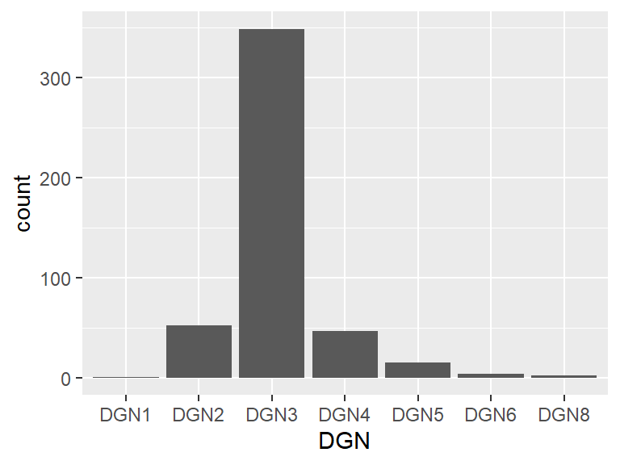

- Note that the following levels have at most five observations: "DGN1", "DGN6", "DGN8".

## PRE4

| Feature | Result |
| --- | --- |
| Variable type | numeric |
| Number of missing obs. | 0 (0 %) |
| Number of unique values | 134 |
| Median | 3.16 |
| 1st and 3rd quartiles | 2.6; 3.81 |
| Min. and max. | 1.44; 6.3 |

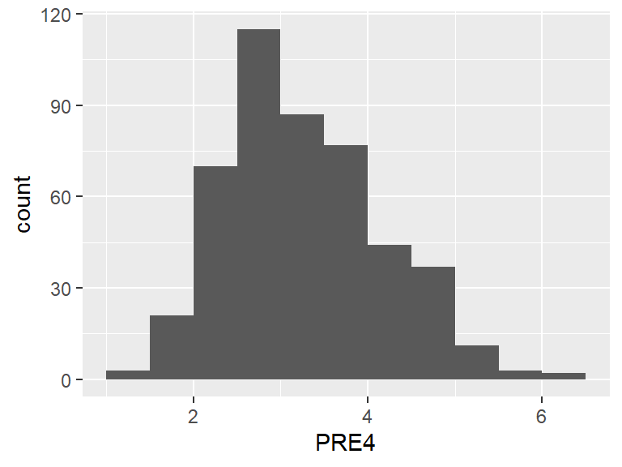

- Note that the following possible outlier values were detected: "1.44", "1.46".

## PRE5

| Feature | Result |
| --- | --- |
| Variable type | numeric |
| Number of missing obs. | 0 (0 %) |
| Number of unique values | 136 |
| Median | 2.4 |
| 1st and 3rd quartiles | 1.96; 3.08 |
| Min. and max. | 0.96; 86.3 |

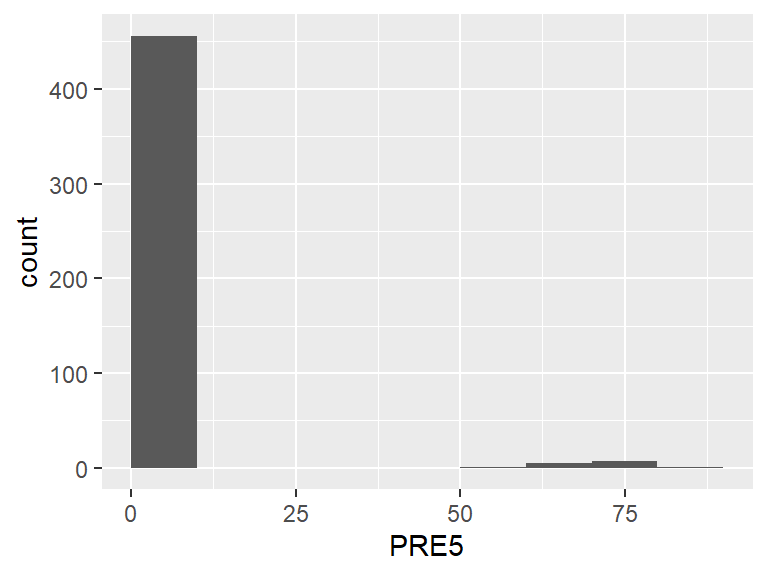

- Note that the following possible outlier values were detected: "0.96", "1", "1.04", "1.12", "1.2", "1.24", "1.28", "1.3", "1.32", "8.56" (14 additional values omitted).

## PRE6

| Feature | Result |
| --- | --- |
| Variable type | factor |
| Number of missing obs. | 0 (0 %) |
| Number of unique values | 3 |
| Mode | “PRZ1” |
| Reference category | PRZ0 |

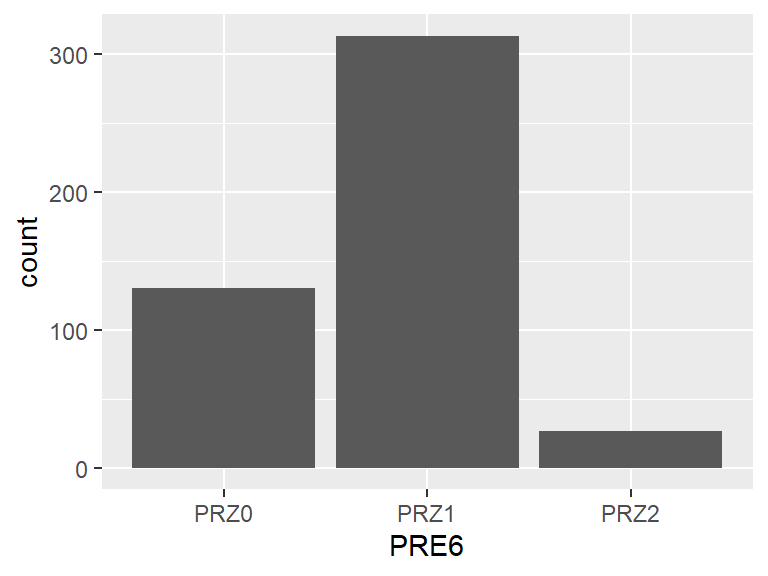

## PRE7

| Feature | Result |
| --- | --- |
| Variable type | factor |
| Number of missing obs. | 0 (0 %) |
| Number of unique values | 2 |
| Mode | “F” |
| Reference category | F |

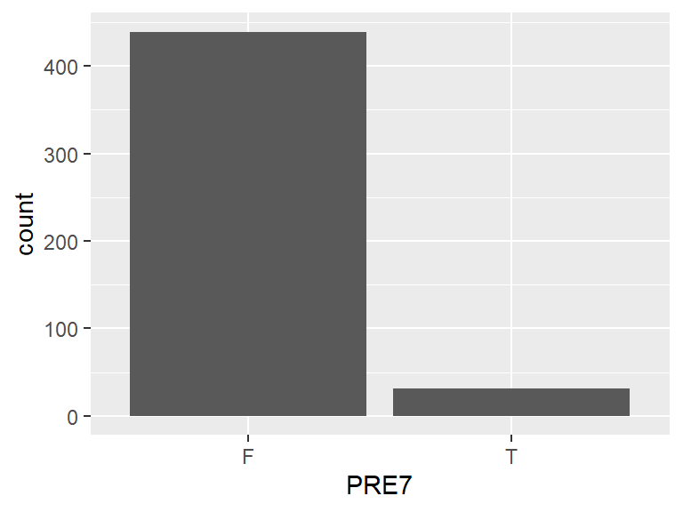

## PRE8

| Feature | Result |
| --- | --- |
| Variable type | factor |
| Number of missing obs. | 0 (0 %) |
| Number of unique values | 2 |
| Mode | “F” |
| Reference category | F |

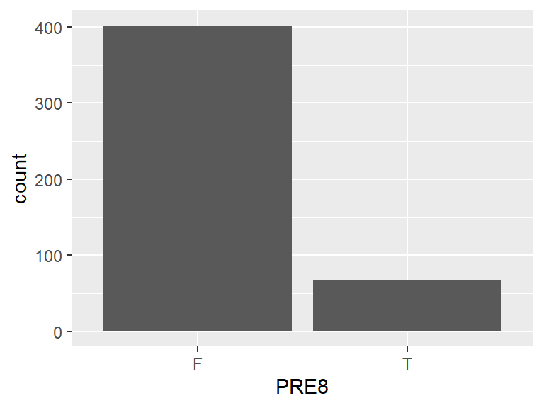

## PRE9

| Feature | Result |
| --- | --- |
| Variable type | factor |
| Number of missing obs. | 0 (0 %) |
| Number of unique values | 2 |
| Mode | “F” |
| Reference category | F |

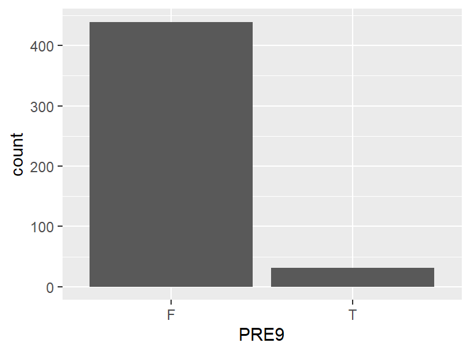

## PRE10

| Feature | Result |
| --- | --- |
| Variable type | factor |
| Number of missing obs. | 0 (0 %) |
| Number of unique values | 2 |
| Mode | “T” |
| Reference category | F |

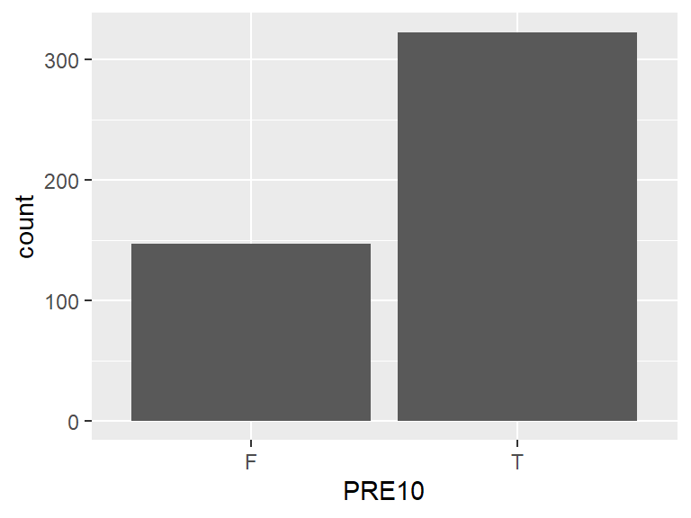

## PRE11

| Feature | Result |
| --- | --- |
| Variable type | factor |
| Number of missing obs. | 0 (0 %) |
| Number of unique values | 2 |
| Mode | “F” |
| Reference category | F |

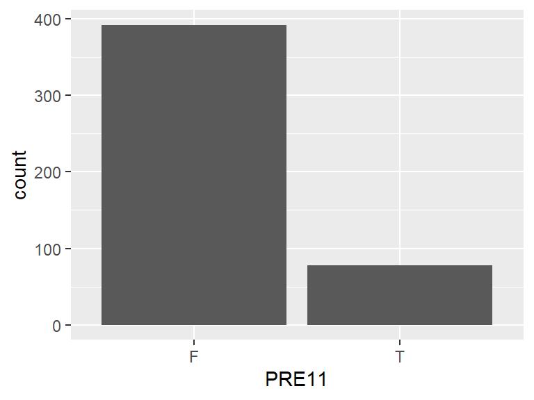

## PRE14

| Feature | Result |
| --- | --- |
| Variable type | factor |
| Number of missing obs. | 0 (0 %) |
| Number of unique values | 4 |
| Mode | “OC12” |
| Reference category | OC11 |

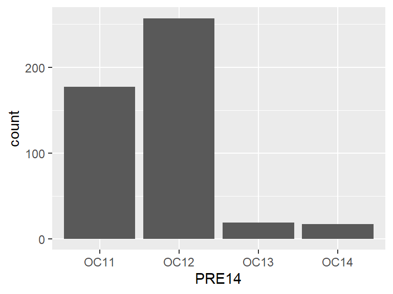

## PRE17

| Feature | Result |
| --- | --- |
| Variable type | factor |
| Number of missing obs. | 0 (0 %) |
| Number of unique values | 2 |
| Mode | “F” |
| Reference category | F |

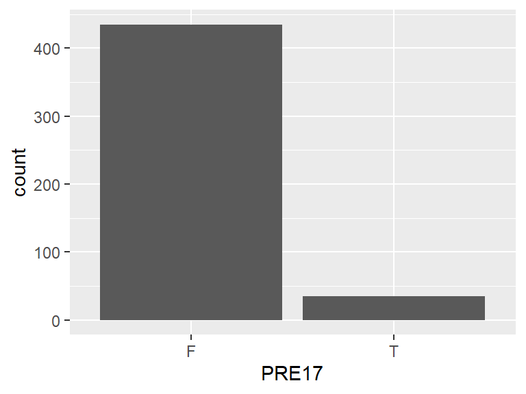

## PRE19

| Feature | Result |
| --- | --- |
| Variable type | factor |
| Number of missing obs. | 0 (0 %) |
| Number of unique values | 2 |
| Mode | “F” |
| Reference category | F |

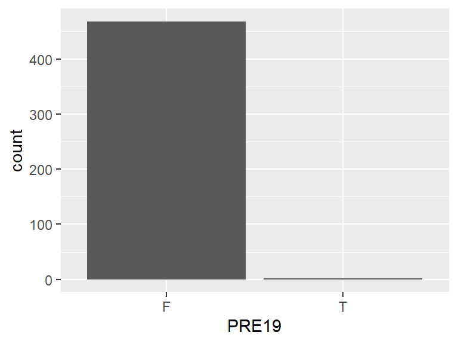

- Note that the following levels have at most five observations: "T".

## PRE25

| Feature | Result |
| --- | --- |
| Variable type | factor |
| Number of missing obs. | 0 (0 %) |
| Number of unique values | 2 |
| Mode | “F” |
| Reference category | F |

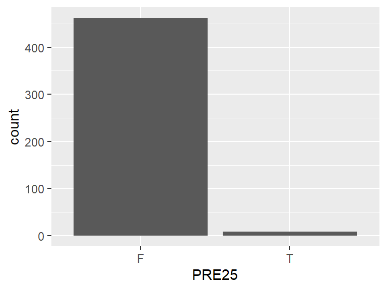

## PRE30

| Feature | Result |
| --- | --- |
| Variable type | factor |
| Number of missing obs. | 0 (0 %) |
| Number of unique values | 2 |
| Mode | “T” |
| Reference category | F |

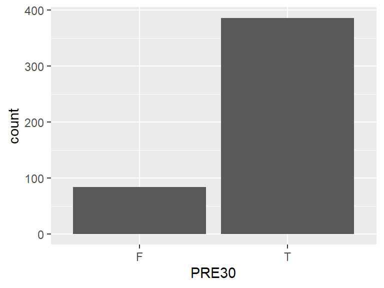

## PRE32

| Feature | Result |
| --- | --- |
| Variable type | factor |
| Number of missing obs. | 0 (0 %) |
| Number of unique values | 2 |
| Mode | “F” |
| Reference category | F |

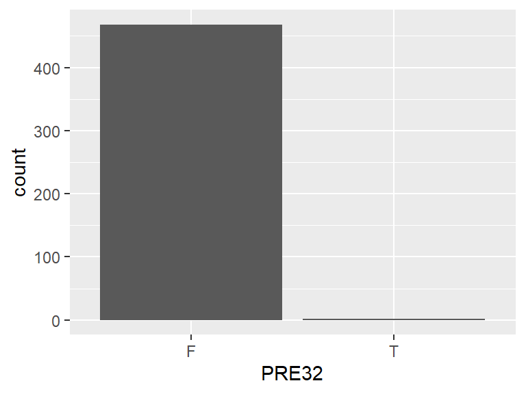

- Note that the following levels have at most five observations: "T".

## AGE

| Feature | Result |
| --- | --- |
| Variable type | numeric |
| Number of missing obs. | 0 (0 %) |
| Number of unique values | 45 |
| Median | 62 |
| 1st and 3rd quartiles | 57; 69 |
| Min. and max. | 21; 87 |

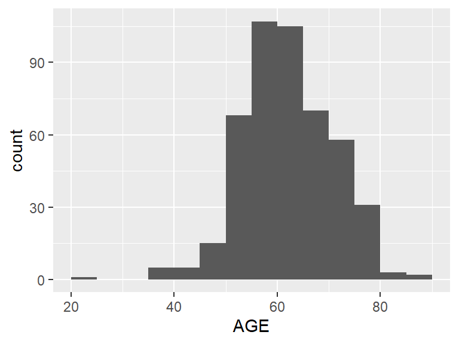

- Note that the following possible outlier values were detected: "21", "37", "38", "39", "40", "41", "44", "45".

## Risk1Yr

| Feature | Result |
| --- | --- |
| Variable type | factor |
| Number of missing obs. | 0 (0 %) |
| Number of unique values | 2 |
| Mode | “F” |
| Reference category | F |

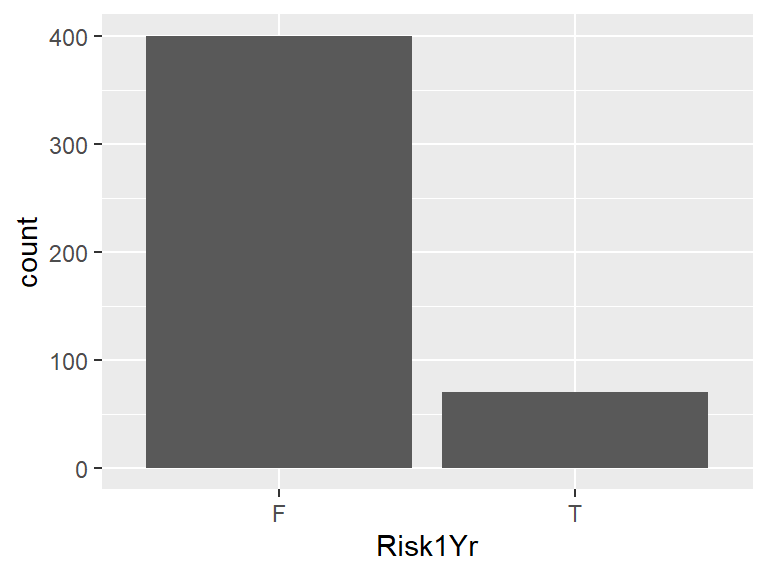

Report generation information:

- Created by: christopherohit (username: `Hendrich`).
- Report creation time: Tue Jun 22 2021 20:51:51
- Report was run from directory: `C:/Users/Hendrich/Desktop/Professional Internship/Death`
- dataMaid v1.4.0 [Pkg: 2019-12-10 from CRAN (R 4.0.5)]
- R version 4.0.5 (2021-03-31).
- Platform: x86_64-w64-mingw32/x64 (64-bit)(Windows 10 x64 (build 19042)).
- Function call: `makeDataReport(data = df, render = FALSE, file = "EDA.Rmd", replace = TRUE)`